# NHTSA DSFS Meta-Analysis

Meta-Analysis of Effectiveness of Dynamic Speed Feedback Signs:

Daniel Flynn Andrew Breck Olivia Gillham Donald L. Fisher

April 2017

Volpe National Transportation Systems Center 55 Broadway Cambridge, MA 02114

# Introduction

Traffic safety engineers and transportation planners have a high interest in the efficacy of different approaches to reducing driver speeds on critical roadway segments. One of these approaches, in particular monitoring traffic speeds in conjunction with installation of Dynamic Speed Feedback Signs (DSFS), has recently been targeted by the Governors’ Highway Safety Association (GHSA). An ongoing review by the Volpe National Transportation Systems Center (Volpe) of the studies conducted to investigate DSFS indicates that the studies have employed similar enough designs and are sufficiently numerous that a meta-analysis to quantitatively summarize the results can be carried out.

Meta-analysis is a statistical technique used to draw general conclusions from a set of related studies focused on similar experimental treatments and responses (Glass 1976). Given sufficiently similar study designs, the size of the treatment effects can be pooled to create a meta-data set, which is then analyzed with appropriate weighting based on the variability and size of each study. This meta-analysis aims to provide decision-makers with a quantitative summary of how much vehicle speed is reduced following installation of a DSFS. Factors such as location, timing, vehicle type, posted speed, safety focus, and others are all considered.

# Methods

## Data collection

1. the descriptor level, which describes the characteristics of each study (the features which identify how the DSFS was implemented, the hypotheses that were evaluated, and the experimental design)
2. the data level, which was the least-aggregated level of data reported either in tabular or graphical format in the publication. For calculations of effect size, at a minimum a study would have to report the mean and standard deviation (SD) of vehicle speeds, as well as the number of vehicles observed, at either two points in time or two locations. The difference in whether studies focused on different timing or location of vehicle speed data collection determines which hypotheses can be tested (see section titled Calculating effect size).

Publications in some cases included more than one study, meaning they tested DSFS at different locations or in combinations with additional treatments such as police cruisers or speed radar enforcement; these are treated as separate studies in the data collection, grouped under the same publication ID. Publications employed many different combinations of descriptors in the study design, and effort was made to enter data from any relevant descriptor that could be expected to appear in multiple studies. Key descriptors included posted speed, safety focus, vehicle type, sign type, and distance from sign the vehicle speeds were measured.

## Calculating Effect Size

Meta-analyses were initially used primarily to assess the odds of a particular outcome, such as the odds a drug treatment would result in a favorable outcome for a patient, and then were expanded to more generally test the size and direction of the outcome across different studies. Both types of tests, assessing odds of a categorical outcome or size of a continuous outcome, are dependent on calculating the effect size. For the meta-analysis of DSFS, the outcomes are vehicle speeds at different points in time. Three sets of hypotheses regarding the effectiveness of DSFS can tested, and each requires a different calculation of effect size:

1. H1. Activation of the DSFS. How much the installation of DSFS reduces driver speed is the central question for this analysis. The studies tested activation in three ways:
   1. Compare vehicle speeds adjacent to the DSFS before activation and then during activation
   2. compare vehicle speeds upstream (of the DSFS) and adjacent (to the DSFS)
   3. Compare the difference between the upstream and adjacent vehicle speeds before activation to the difference between the upstream and adjacent vehicle speeds during activation of the DSFS. This is the ideal comparison, or the true effect (Cruzado and Donnell 2009).
2. H2. Activation of the DSFS: downstream. The studies tested the activation effect downstream in three ways:
   1. Compare downstream vehicle speeds during activation to downstream vehicle speeds before activation,
   2. Compare downstream vehicle speeds adjacent to the DSFS during activation,
   3. Compare a difference of differences which controls for variations in both the time at which the vehicle speeds are measured and the location at which the vehicle speeds are measured.
3. H3. Deactivation of the DSFS. The comparisons are similar to the above, but now vehicle speeds are compared at the DSFS location after the DSFS has been removed to vehicle speeds at the DSFS while the DSFS was activated, or a normalized difference from after to before or after to during installation.

We estimate the effect size (ES) associated with activation of the DSFS appropriately for each hypothesis. The calculation of effect sizes are based on the difference between the mean speeds adjacent to the DSFS during the period in which it is active,
$$\bar{X}_{DSFS}$$
The sample mean speed adjacent the DSFS before activation is defined as
$$\bar{X}_{Before}$$
The ES is this difference, placed relative to units of the pooled standard deviation:
$$ES = \frac{\bar{X}_{DSFS} - \bar{X}_{Before}}{SD_{Pooled}}$$

Where the pooled standard deviation for this calculation is defined as follows:

$$SD_{Pooled} = \sqrt{\frac{(N_{DSFS}-1)SD_{DSFS}}{N_{DSFS} + N_{Before} -2 } + \frac{(N_{Before}-1)SD_{Before}}{N_{DSFS} + N_{Before} -2 }}$$

This effect size calculation is also referred to as the standardized mean difference (Hedges and Olkin 1985). The pooled standard deviation is calculated following standard calculations.

Effect sizes based on normalized “true effects” require a slightly modified calculation, where differences in means rather than means themselves are compared. For example, when the activation effect of the DSFS on vehicle speed is normalized for differences during and before installation, at both the site adjacent to the sign and upstream of the sign, the effect size is calculated as follows:

$$ES = \frac{(\bar{X}_{Adjacent DSFS} - \bar{X}_{Adjacent Before}) - (\bar{X}_{Upstream DSFS} - \bar{X}_{Upstream Before})}{SD_{Pooled}}$$

The pooled standard deviation in this case is computed as follows:

$$SD_{Pooled} = \sqrt{\frac{(N_{1}-1)SD_{1} + (N_{2}-1)SD_{2} + (N_{3}-1)SD_{3} + (N_{4}-1)SD_{4} }{N_{1}+N_{2} + N_{3} + N_{4} - 4}}$$

The subscripts on each variable identify there relevant time and location at the which the variable is measured: 1. Adjacent to the DSFS; 2. Adjacent, Before installation; 3. Upstream of the DSFS; and 4. Upstream of the DSFS, Before installation. Figures 4-7 in the Literature Review provide the detailed speed reduction formulas for each of the 13 possible combinations of timing and location of vehicle speeds in response to DSFS installation. The specific calculations follow the two forms above, for either the direct or normalized measurement of effect size.

All of the effect size calculations and calculations of sample variability $v_{i}$ (see Hypothesis testing) were carried out in the meta-analysis package *metafor* (Viechtbauer 2010) in the statistical programming language *R* (R Core Team 2016). Hypothesis testing (below) was carried out using the linear mixed-effect model package *lme4* (Bates, et al. 2015). The effect size calculations in metafor have been validated against results provided by the software packages Stata, SAS, and SPSS; the results from these other packages either agreed completely or fell within a margin of error expected when using numerical methods. The results of *metafor* effect size calculations and analyses have also been validated against textbook examples.

## Hypothesis testing

This meta-analysis investigates a single continuous outcome (speed of vehicles) across multiple studies, with several moderating variables (e.g., posted speed, safety focus, time of day). The use of multiple moderating variables in a meta-analysis has also been called meta-regression (van Houwelingen, Arends and Stijnen 2002). This type of analysis is best conducted using a mixed-effect model, where studies are the random effects, and the moderating variables are the fixed effects. “Random effects” refers to variables in the model which are assumed to be representatives of a larger population (Raudenbush 2009, Hedges and Vevea 1998), which in this case are the publications and studies within each publication. The studies examined in this analysis are assumed to be representatives of other possible studies that might have been done. Statistically, random effects are variables which are themselves modeled, with their own error terms. “Fixed effects” refers to predictor variables in the model which are directly measured for each study.

$$y_{i} = \beta_{0} + \beta_{1}posted speed + \beta_{2} vehicle type+\beta_{3}safety focus + u_{i} + e_{i}$$

where *i* indexes the study. $\beta_{0}$ refers to the overall intercept, while the terms $\beta_{1}$, $\beta_{2}$, and $\beta_{3}$ refer to the coefficients for each of teh predictor variables.

The error term has two parts, first the study-level error term $u_{i}$, which is defined as $u_{i} \sim N(0, \tau^{2})$, a normally distributed error term with a mean of zero and variance $\tau^{2}$; this variance is estimated in the model, and is the random effect in the model. As a random effect, it represents the variability assumed from the larger population of studies from which the specific studies used have been drawn. The remaining error term $e_{i}$ is defined as $e_{i} \sim N(0, v_{i})$, meaning that the residual error is normally distributed with a mean of zero and a variance of $v_{i}$; this variance $v_{i}$ is directly computed in the effect size calculation. The sampling variance $v_{i}$ becomes important in the model fitting process, giving greater weight to studies which have a lower variability in the response, due to a large sample size, a low standard deviation in the speeds, or a combination of the two.

For each of the 13 hypotheses tested, a similar structure of models was used. Establishing which moderator variables (descriptors) should be used will be the critical step in the analysis, as not all studies provide complete information on all of the moderating variables.

This analysis allows results to be presented on the overall effectiveness of DSFS in reducing speeds for a particular hypothesis, for example the overall effect of DSFS activation when comparing speeds measured at the DSFS sign to speeds measured at the site of the DSFS sign, prior to sign installation (Hypothesis H1B). In addition to this overall measure of speed reduction, this analysis will further allow reporting of how much the posted speed drives the speed reduction, how much the speed reduction differs for passenger cars versus commercial vehicles, and how much the speed reduction differs for school zones, work zones, rural-to-urban transition zones, or other safety focus areas. The combination of multiple hypotheses tested and multiple moderating variables should assist states in determining where and when to deploy DSFS for maximum effect, and the size of the speed reduction they can expect to observe.

# Results

## Summary of data

Summary of the number of publications, studies, and individual sites which can be used to test each of the 13 hypotheses.

|  | Publications | Studies | Sites |
| --- | --- | --- | --- |
| H1A | 12 | 22 | 81 |
| H1B | 18 | 36 | 186 |
| H1C | 14 | 28 | 123 |
| H2A | 9 | 18 | 85 |
| H2B | 9 | 18 | 85 |
| H2C | 9 | 18 | 85 |
| H2A’ | 9 | 18 | 85 |
| H2C’ | 9 | 18 | 85 |
| H3A | 2 | 3 | 8 |
| H3B | 3 | 5 | 8 |
| H3C | 2 | 3 | 4 |
| H3A’ | 2 | 3 | 4 |
| H3B’ | 3 | 5 | 8 |

## Activation hypothesis: H1

The three versions of hypothesis H1 all rely on a measurement of vehicle speeds at the site of the DSFS, but use different baseline comparisons. The simplest, H1B, compares vehicle speeds at the site of the sign between the time before activation and during activation. H1A calculates a similar value, for the difference between activation timing (before and during), normalized to the same difference upstream of the DSFS. H1C compares speeds at the DSFS to speeds upstream, at the same time.

### H1A: Activation normalized

Examining the mean effect sizes across vehicle types, without carrying out any statiticaly modeling, it is clear that the largest decreases in speed were observed for passenger cars.

Decreases in speed for Hypothesis H1A, normalized activation effect of DSFS, by vehicle type.

| Vehicle Type | Effect size yi | Variance vi | N |
| --- | --- | --- | --- |
| Unspecified | -2.729 | 0.278 | 31 |
| Passenger | -3.905 | 1.035 | 16 |
| Truck | -1.973 | 4.401 | 25 |

Summary of mixed effect model of hypothesis H1A, difference in speeds betwen DSFS before and at time of activation, normalized to the difference before and at time of activation upstream of the sign.

[output not shown]

## H1B

Decreases in speed for Hypothesis H1B, activation effect of DSFS, by location and vehicle type.

| Location | Vehicle Type | Effect size yi | Variance vi | N |
| --- | --- | --- | --- | --- |
| 1 upstream | Unspecified | -0.232 | 0.153 | 52 |
| 2 adjacent | Unspecified | -2.687 | 0.136 | 130 |
| 3 downstream | Unspecified | -3.072 | 0.195 | 28 |
| 1 upstream | Passenger | -0.476 | 0.470 | 59 |
| 2 adjacent | Passenger | -4.521 | 0.601 | 97 |
| 3 downstream | Passenger | -2.725 | 0.411 | 72 |
| 1 upstream | Truck | 0.394 | 2.167 | 92 |
| 2 adjacent | Truck | -2.129 | 1.717 | 121 |
| 3 downstream | Truck | -2.207 | 0.879 | 74 |

Summary of mixed effect model of hypothesis H1B, difference in speeds betwen DSFS before and at time of activation.

|  | Estimate | Std. Error | t value |
| --- | --- | --- | --- |
| (Intercept) | -0.578 | 0.562 | -1.030 |
| location2 adjacent | -2.844 | 0.399 | -7.128 |

```
## Computing p-values via Kenward-Roger approximation. Use `p.kr = FALSE` if computation takes too long.
```

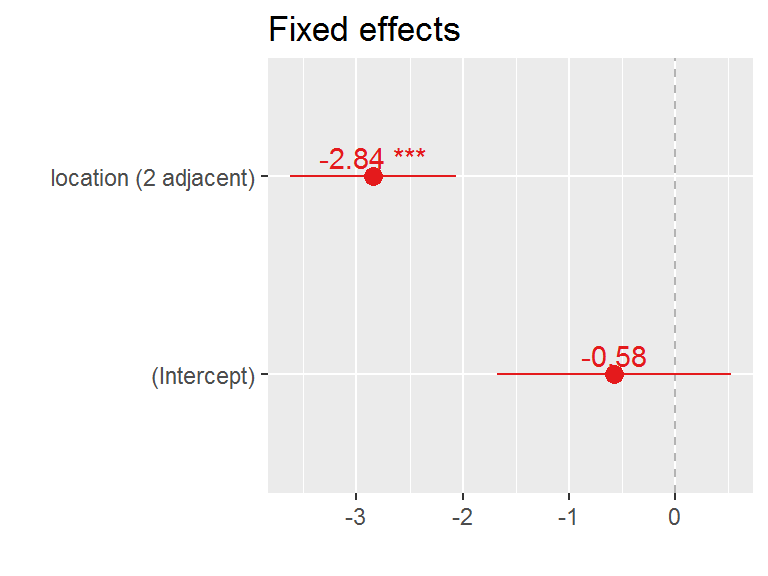

## H1C

| Vehicle Type | Effect size yi | Variance vi | N |
| --- | --- | --- | --- |
| Unspecified | -11.128 | 0.070 | 31 |
| Passenger | -1.704 | 1.585 | 16 |
| Truck | -1.424 | 2.920 | 25 |

Summary of mixed effect model of hypothesis H1C, difference in speeds between DSFS upstream and adjacent to the sign.

|  | Estimate | Std. Error | t value |
| --- | --- | --- | --- |
| (Intercept) | -8.615 | 3.254 | -2.647 |

```
## Computing p-values via Kenward-Roger approximation. Use `p.kr = FALSE` if computation takes too long.
```

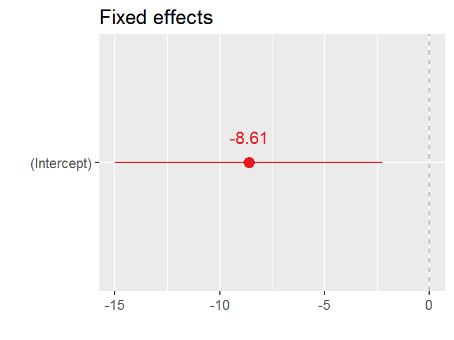